# Slurm batch jobs – part II

Week 9 – Lecture B

Author

Affiliations

Jelmer Poelstra

[CFAES Bioinformatics Core, Ohio State University](https://go.osu.edu/bioinformatics-core)

[Dept. of Plant Pathology, Ohio State University](https://plantpath.osu.edu)

Published

October 3, 2026

## 1 Introduction

### 1.1 Learning goals

Now that you know the basics of submitting and managing Slurm batch jobs, you will learn:

- The most common Slurm/`sbatch` options, including those to request:
  - More time, cores, and memory for jobs
  - An email notification when jobs e.g. fail or finish
- How to run Slurm jobs in practice, including how to submit many jobs at the same time
- How to make sure that your jobs succeeded

### 1.2 Getting ready

1. At https://ondemand.osc.edu, start a VS Code session in `/fs/ess/PAS3493/users/$USER`
2. In the terminal, navigate to your `week09` dir

### 1.3 Testing the Shellcheck extension

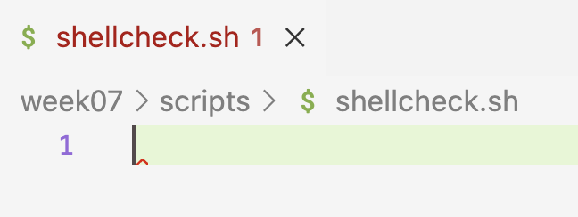

Above: Shellcheck will show a red squiggly line if the shell script is empty.  
Below: Hover over the squiggly line to see what this warning is about.

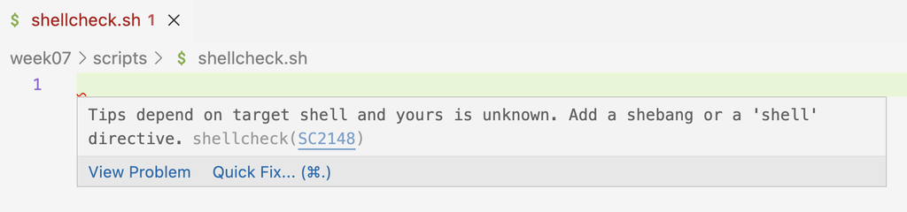

3. So, Shellcheck wants you to add a shebang line, and once you do so, the squiggly line disappears:

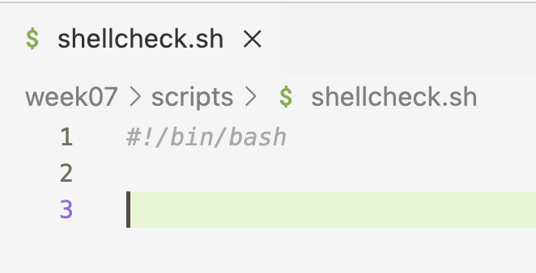

4. That was one example of a handy Shellcheck tip. Another is when you have assigned a variable, but don’t use (reference it):

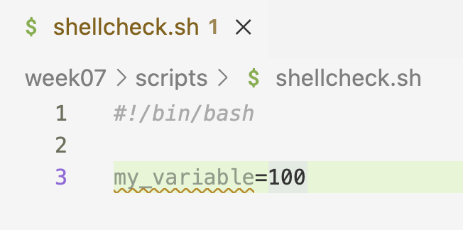

Above: Shellcheck will show an orange squiggly line when you’ve assigned a variable that you don’t use.  
Below: Hovering over the line again tells you the reason for the warning.

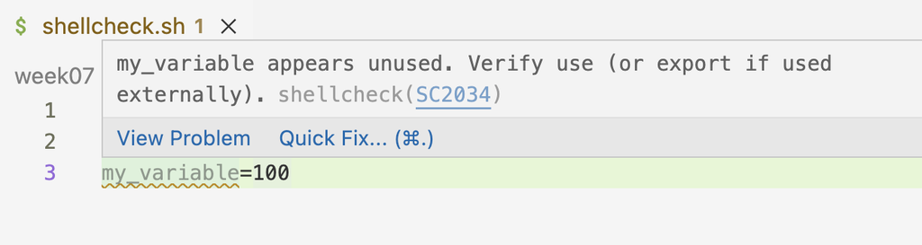

4. Referencing the variable in question makes the squiggly line disappear:

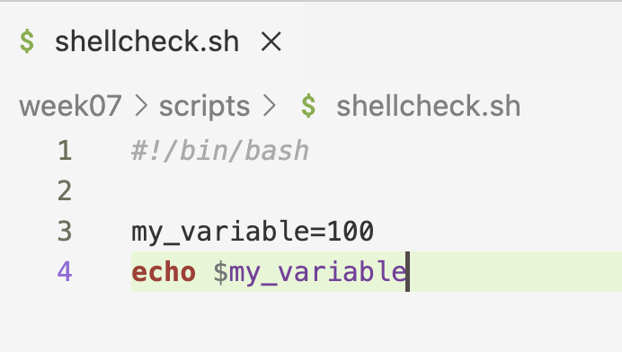

5. Conversely, when you reference a variable that hasn’t been assigned:

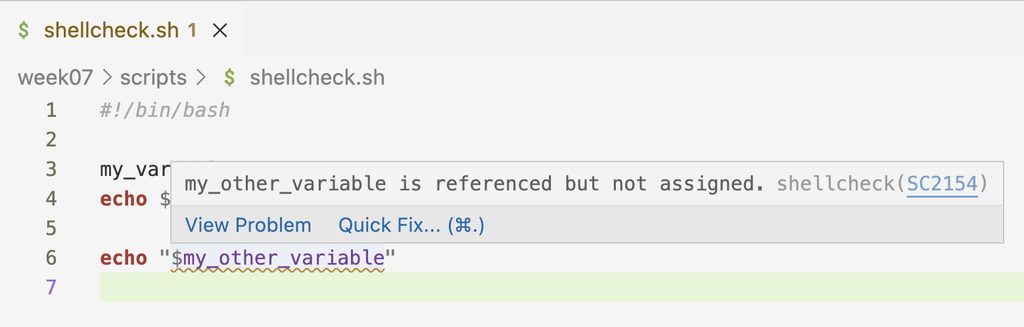

6. These tips can be extremely useful! Also in cases where you e.g. make a typo in a variable name, or renamed a variable but didn’t do so consistently.

## 2 Common Slurm/`sbatch` options

Here, we’ll go through the most commonly used `sbatch` options (except `--account`, which was covered in the previous lecture). As pointed out above, each of these options can be:

- passed on the command line: `sbatch --account=PAS3493 myscript.sh` *(has precedence over the next)* and/or
- added at the top of the script you’re submitting: `#SBATCH --account=PAS3493`.

Also, note that many options have a corresponding long (e.g. `--account=`) and short format (e.g `-A`). For clarity, we’ll stick to long-format options here.

### 2.1 Time with `--time`

If you suspect or know that the default time limit of 1 hour may not be enough for your job, use the `--time` option to request more time. Note that tour job will be **killed** (stopped) as soon as it hits the time limit!

For single-node jobs, up to 168 hours / 7 days can be requested. (If that’s not enough, you can request access to a separate queue for long jobs of up to 14 days, called the `longserial` queue.)

OSC bills projects for **the time that jobs actually used**, not what you reserved. And recall that batch jobs will stop as soon as the focal script has finished running. But before you decide to ask for 168 hours for every job, note that jobs that request more time are likely to have to wait longer before they start.

**TipThe time your reserve is the “**wall time**”**

When you reserve an amount of time with `--time`, this is the “wall time”. What does wall time mean? This is simply the actual amount of time that passes on the (wall) clock. This term is used to contrast it with “*core hours*”, which is the number of hours multiplied by the number of cores:

| # hours | # cores | wall time | # core hours |
| --- | --- | --- | --- |
| 2 | 1 | 2 | 2 |
| 2 | 8 | 2 | 16 |

A number of formats can be used to specify the time, including:

| Format | Example | Meaning |  |
| --- | --- | --- | --- |
| minutes | `60` | 60 minutes |  |
| hours:minutes:seconds | `1:00:00` | 60 minutes |  |
| days-hours | `2-12` | two-and-a-half days (60 hours) |  |

For example, requesting 2 hours in the “minute-format” inside a shell script:

```bash
#!/bin/bash
#SBATCH --time=120
```

**ImportantWhen in doubt, request more time!**

It is common to be uncertain about how much time your job will take (i.e., how long it will take for your script to finish). Whenever this happens, ask for more, perhaps much more, time than what you think/guesstimate you will need. It is really annoying to have a job run out of time after several hours, while the increase in queueing time for jobs that request more time is often quite minimal at OSC.

#### Exercise: exceed the time limit

Modify the `sleep.sh` script to reserve only 1 minute for the job, while making the script run for longer than that by increasing the `sleep` sleeping time to at least 100 seconds.

If you succeed in exceeding the time limit, an error message will be printed. Where do you think this error message will be printed: to the screen, in the Slurm log file, or in `sleep.txt`?

After waiting for the job to be killed after 60 seconds, check if you were correct and what the error message is.

### 2.2 Cores with `--cpus-per-task`

First, note that Slurm mostly uses the terms “core” and “CPU” interchangeably[^1]. More generally with bioinformatics tools, “thread” is also commonly used interchangeably with core/CPU[^2]. Therefore, for our purposes, you can **think of “core”, “CPU”, and “thread” as synonyms** that all refer to the same sub-parts/components of a node that you can reserve and use separately.

Running a bioinformatics program with multiple threads/cores/CPUs (“multi-threading”) is very common, and this can make the running time of such programs much shorter. While the specifics depend on the program, using **8-12 cores** is often a sweet spot, whereas asking for even more cores can lead to rapidly diminishing returns.

While there are multiple relevant Slurm options (see the box below), I recommend that you specify the number of threads/cores/CPUs with the option **`--cpus-per-task`** (`-c`).

Typically, inside your shell script, you will also want to inform the program that your script runs about the number of available cores – most have an option like `--cores` or `--threads`. **You should set this to the same value `n` as the `--cpus-per-task`.** An example, where we ask for 8 CPUs/cores/threads:

```bash
#!/bin/bash
#SBATCH --cpus-per-task=8

# And we tell a fictional program about that number of cores:
trimming_program.py --cores 8 sampleA_R1.fastq.gz
```

**NoteWhat about nodes and tasks? *(Click to expand)**

You may have noticed that the long form of the above option is `--cpus-per-task` instead of just, say, `--cpus`. What is that about? Let’s go over nodes and tasks:

- Tasks are independent processes that a computer can run. And recall that nodes are the large computers that a supercomputer is made of.
- In bioinformatics, running multiple processes (tasks) or needing multiple nodes in a single batch job is *not* common.
- You can specify the number of nodes with `--nodes` and the number of tasks with `--ntasks` and/or `--ntasks-per-node`; all have defaults of 1 (see the table below).
- Unless you have very clear reasons to, I recommend not to use the abovementioned options to change the number of tasks or nodes, so your job will have 1 of each. When you do this, the above `-c` option simply specifies the number of cores.
- For example, only ask for **more than one node** when a program is parallelized with e.g. “MPI”, which is rare in bioinformatics.
- For jobs that require multiple processes (tasks), you can use `--ntasks=n` or `--ntasks-per-node=n` — this is also quite rare! However, note in practice, specifying the number of tasks `n` with one of these options is equivalent to using `--cpus-per-task=n`, in the sense that both ask for `n` cores that can subsequently be used by a program in your script. Therefore, some people use `tasks` as opposed to `cpus` for multi-threading, and you may run across this in the OSC documentation too. (Yes, this is confusing!)

Here is an overview of the options related to cores, tasks, and nodes:

| Resource/use | short | long | default |
| --- | --- | --- | --- |
| Nr. of cores/CPUs/threads (per task) | `-c 1` | `--cpus-per-task=1` | 1 |
| Nr. of “tasks” (processes) | `-n 1` | `--ntasks=1` | 1 |
| Nr. of tasks per node | - | `--ntasks-per-node=1` | 1 |
| Nr. of nodes | `-N 1` | `--nodes=1` | 1 |

### 2.3 RAM memory with `--mem`

The `--mem` option specifies the maximum amount of RAM (Random Access Memory) available to your job.

The **default** amount of memory will depend on how many cores you reserved. Standard cores have 4 GB of memory “on it”, and therefore, the default amount of memory you will get is 4 GB is per reserved core. For example, if you specify `--cpus-per-task=4`, you will have 16 GB of memory. And the default number of cores is 1, which gives you 4 GB.

Like with the time limit, your job gets **canceled** by Slurm when it hits the memory limit (see the box below).

Because it is common to ask for multiple cores and due to the above-mentioned adjustment of the memory based on the number of cores, you will often end up having enough memory automatically, and won’t need to use the `--mem` option.

The maximum amount of memory you can request on regular Pitzer compute nodes is 178 GB. If you need more than that, you should use one of the specialized `largemem` or `hugemem` nodes — switching to such a node generally happens automatically based on your requested amount[^3] — see [this OSC page for details on node types and associated memory on Pitzer](https://www.osc.edu/resources/technical_support/supercomputers/pitzer/batch_limit_rules).

The default `--mem` unit is MB (MegaBytes); append `G` for GB (i.e. `100` means 100 MB, `10G` means 10 GB). For example, to request 20 GB of RAM:

```bash
#!/bin/bash
#SBATCH --mem=20G
```

**WarningIt is not always clear what happened when your job ran out of memory *(Click to expand)**

Whereas you get a very clear Slurm error message when you hit the time limit (as seen in the exercise above), hitting the memory limit can result in a variety of errors.

But look for keywords such as “Killed”, “Out of Memory” / “OOM”, and “Core Dumped”, as well as actual “dumped cores” in your working dir (large files with names like `core.<number>`, these can be deleted).

If you see these or otherwise suspect that your job ran out of memory, resubmit it with an increased requested amount of memory.

**NoteHow to request a non-default node type *(Click to expand)**

To request that a bach job runs on a non-default node type, you should use the `--partition` option. For example:

```bash
#!/bin/bash
#SBATCH --partition=hugemem
#SBATCH --mem=900G
```

#### Exercise: Adjusting cores and memory

Think about submitting a shell script that runs a bioinformatics tool like FastQC as a batch job, in the following two scenarios:

1. The program has an option `--cores`, and you want to set that to 12. The program also says you’ll need 60 GB of memory. Which relevant `#SBATCH` option values will you use?
2. The program has an option `--threads`, and you want to set that to 8. The program also says you’ll need 25 GB of memory. Which relevant `#SBATCH` option values will you use?

### 2.4 Slurm log file names with `--output`

As you saw above, output from a script that would normally be printed to screen will end up in a Slurm log file when it is submitted as a batch job. By default, this file is created in the directory from which you submitted the script, and is called `slurm-<job-number>.out`, e.g. `slurm-12431942.out`.

But it is possible to change the name of this file. For instance, it can be useful to include the **name of the bioinformatics program** that the script runs (or another kind of keyword describing the function of the script), so that it’s easier to recognize this file later. You can do this with the `--output` option, e.g. `--output=slurm-fastqc.out` if you were running FastQC.

But you’ll generally want to keep the batch job number in the file name too[^4]. Since you won’t know the batch job number in advance, you need a trick here – and that is to use **`%j`**, which represents the batch job number:

```bash
#!/bin/bash
#SBATCH --output=slurm-fastqc-%j.out
```

**NoteThe output streams `stdout` and `stderr`, and separating them**

The output that programs (including basic Unix commands) print to screen can be divided into two types:

1. **Standard output** (`stdout`) for regular output
2. **Standard error** (`stderr`) for error messages and sometimes warnings messages

Most of the time, it’s not obvious that these are two separate types, but it possible to treat them separately. For example, while both `stdout` and `stderr` by default end up in the same Slurm log file, it is possible to separate them into different files. You can do that by using the `--error` option, e.g.:

```bash
#SBATCH --output=slurm-fastqc-%j.out
#SBATCH --error=slurm-fastqc-%j.err
```

In the above example, only `stdout` will go into the file specified with `--output`, and `stderr` will go into the file specified with `--error`. Separating `stdout` and `stderr` like that could be useful because it may make it easier to spot errors, and an empty `--error` file would mean that there were no errors.

However, reality is more messy: some programs print their main output (results) not to a file but to standard out, in which case all logging output, i.e. errors and regular messages alike, is designated as standard error. And some other programs use *stdout* for all messages. Therefore, with Slurm, I personally only specify `--output`, such that both `stdout` and `stderr` end up in that file.

### 2.5 Notification emails with `--mail-type`

You can use the `--mail-type` option to receive emails when a job begins, completes successfully, or fails. You don’t have to specify your email address: you’ll be automatically emailed on the address linked to your OSC account. I would recommend that for…

- **Shorter-running jobs** (roughly up to a few hours): only have Slurm send emails if they fail (`--mail-type=FAIL`). Especially when you submit many jobs at a time, you may otherwise overlook failure for some jobs.

  ```bash
  #!/bin/bash
  #SBATCH --mail-type=FAIL
  ```

- **Longer-running jobs**, have Slurm send emails both for failed and successfully completed jobs (`--mail-type=END,FAIL`). This is helpful because you don’t want to have to keep checking in on jobs that run for many hours[^5].

  ```bash
  #!/bin/bash
  #SBATCH --mail-type=END,FAIL
  ```

**TipGet warned when your job is close to its time limit *(Click to expand)**

You may also find the `--mail-type` values `TIME_LIMIT_90`, `TIME_LIMIT_80`, and `TIME_LIMIT_50` useful for very long-running jobs, which will warn you when the job is at 90/80/50% of the time limit. For example, it is possible to email OSC to ask for an extension on individual jobs. You shouldn’t do this often, but if you have a job that ran for 6 days and it looks like it may time out, this may well be worth it.

### 2.6 Table with `sbatch` options

Here are the main options we discussed above:

| Resource/use | long option example | short option | default |
| --- | --- | --- | --- |
| Project to be billed | `--account=PAS3493` | `-A` | *N/A* |
| Time limit | `--time=4:00:00` | `-t` | 1:00:00 |
| Nr of cores | `--cpus-per-task=1` | `-c` | 1 |
| Memory limit per node | `--mem=4G` | - | 4G |
| Log output file | `--output=slurm-fastqc-%j.out` | `-o` |  |
| Put error output (*stderr*) from into a separate file | `--error=slurm-fastqc-%j.err` |  |  |
| Get email when job ends / ends or fails | `--mail-type=END` `--mail-type=END,FAIL` | - |  |

And some additional ones:

| Resource/use | long option example |
| --- | --- |
| Job name (will e.g. be displayed in `squeue` output) | `--job-name=fastqc` |
| Partition (=queue type) | `--partition=longserial` `--partition=hugemem` |
| Only allow job to begin after a specific time | `--begin=2026-04-05T12:00:00` |
| Only allow job to begin after another job has successfully finished | `--dependency=afterok:123456` |
| Nr of nodes | `--nodes=1` |
| Nr of “tasks” (processes) | `--ntasks=1` |
| Nr of tasks per node | `--ntasks-per-node=1` |

## 3 Batch job examples with FastQC

Last week, we used a `for` loop to run FastQC interactively for every FASTQ file. This ran quickly, but keep in mind that our practice FASTQ files are only 5% of their original sizes. Additionally, other bioinformatics programs may take much longer. To speed things up, and not block the terminal while programs are running, we will submit a batch job for each sample/file, so that many jobs can run simultaneously[^6].

So, let’s practice with submitting a batch job for each FastQC run. We’ll first submit a job for a single file, and then loop over all files to submit many jobs. You should have the FastQC script in `scripts/fastqc.sh` – if not, see the box below.

**Note…Or create a new script and copy this code into it *(Click to expand)**

```bash
#!/bin/bash
set -euo pipefail

# Load the OSC module for FastQC
module load fastqc/0.12.1

# Copy the placeholder variables
fastq="$1"
outdir="$2"

# Initial logging
echo "# Starting script fastqc.sh"
date
echo "# Input FASTQ file:   $fastq"
echo "# Output dir:         $outdir"
echo

# Create the output dir if needed
mkdir -p "$outdir"

# Run FastQC
fastqc --outdir "$outdir" "$fastq"

# Final logging
echo
echo "# Used FastQC version:"
fastqc --version
echo
echo "# Successfully finished script fastqc.sh"
date
```

### 3.1 Modify the script for usage with Slurm

Next, add Slurm options with the following `#SBATCH` lines in the script – note that you’ll ask for 4 cores:

```bash
#!/bin/bash
#SBATCH --account=PAS3493
#SBATCH --cpus-per-task=4
#SBATCH --mail-type=FAIL
#SBATCH --output=slurm-fastqc-%j.out
```

When you have multiple cores at your disposal in a batch job, you should almost always **explicitly tell the program that you’re running about this**. Some programs default to using 1 core while others try to auto-detect the number of cores, but any auto-detection tends to be inappropriate: the program would detect the total number of cores on the OSC node rather than the number that we have reserved.

#### Exercise: Let FastQC use multiple cores

Change the FastQC command in the script so that FastQC will use all 4 reserved cores. Run `fastqc --help` to find the relevant option.

**Click to see the solution**

The relevant section of the Help text:

```
 -t --threads    Specifies the number of files which can be processed
                 simultaneously.  Each thread will be allocated 250MB of
                 memory so you shouldn't run more threads than your
                 available memory will cope with, and not more than
                 6 threads on a 32 bit machine
```

Let FastQC know how many cores you have reserved by *editing the command* to include `--threads 4`:

```bash
fastqc --threads 4 --outdir "$outdir" "$fastq"
```

### 3.2 Submit a single test batch job

Now, you’re ready to submit the script. Let’s test it for one sample first:

```bash
# We'll assign the FASTQ file to a variable first
# (e.g. to shorten the next sbatch command):
fastq_file=../garrigos-data/fastq/ERR10802863_R1.fastq.gz
ls -lh "$fastq_file"
```

[output not shown]

```bash
sbatch scripts/fastqc.sh "$fastq_file" results/fastqc
```

```
Submitted batch job 37615710
```

#### Monitor the batch job

Next, monitor your job by checking its status in the Slurm queue:

```bash
squeue -u $USER -l
```

```
Tue Sep 30 09:21:48 2025
             JOBID PARTITION     NAME     USER    STATE       TIME TIME_LIMI  NODES NODELIST(REASON)
          37615710   cpu-exp fastqc.s   jelmer  RUNNING       0:01   1:00:00      1 p0510
```

After a while:

- You will know that your job has stopped running (either due to failure or because it finished succesfully) when it is no longer listed in the `squeue` output
- If you additionally didn’t receive an email from Slurm, this implies the job succeeded – job failure should have triggered an email due to the `#SBATCH --mail-type=FAIL` line.

#### Check the output files

Even if you’ve inferred that your job succeeded from the abovementioned clues, don’t forget to look at the output files to confirm this:

- **Slurm log file**: The combination of having strict bash `set` settings and the “*Succesfully finished*” `echo` line at the end of the script means that if you see that line printed, the script encountered no errors. Nevertheless, you should also look at the rest of this file, because a program’s “logging statements” may have useful information, including output summaries but also warnings.
- **The program’s main output files**: As discussed, most bioinformatics tools don’t just print “logging” information that ends up in the Slurm log file, but will also have output files (in the case of of FastQC, and HTML and a Zip file). Therefore, always check the output dir for the presence of such output files.

Checking the Slurm log file:

- Make sure it’s there:

  ```bash
  ls
  ```

  ```
  slurm-fastqc-37615710.out
  ```

- Quick check that the “marker” line that indicates a successful run is printed:

  ```bash
  tail slurm-fastqc*.out
  ```

  ```
  ==> slurm-fastqc-37615710.out <==
  Approx 90% complete for ERR10802863_R1.fastq.gz
  Approx 95% complete for ERR10802863_R1.fastq.gz
  Approx 100% complete for ERR10802863_R1.fastq.gz
  Analysis complete for ERR10802863_R1.fastq.gz

  # Used FastQC version:
  FastQC v0.12.1

  # Successfully finished script fastqc.sh
  Tue Sep 30 09:21:51 AM EDT 2025
  ```

- Take a closer look at the file:

  ```bash
  less slurm-fastqc*
  # [output not shown]
  ```

Finally, check for the presence of the main FastQC output files:

```bash
ls -lh results/fastqc
```

```
total 1.1M
-rw-rw----+ 1 jelmer PAS0471 718K Sep 30 09:21 ERR10802863_R1_fastqc.html
-rw-rw----+ 1 jelmer PAS0471 364K Sep 30 09:21 ERR10802863_R1_fastqc.zip
```

**TipPay attention to file sizes**

It can also be a good idea to pay attention to the sizes of output files, as shown by `ls -lh`. Especially if you’re not going to open the output files right away, this can be yet another clue as to whether the program succeeded. When they fail, some programs programs produce empty or extremely small output files – their presence should always be a red flag.

#### Clean up

Because this was a test-run, and you will now run a loop to analyze each sample, let’s remove the outputs:

```bash
rm -r results/fastqc slurm-fastqc*
```

#### Exercise: Trigger a job failure email

1. Submit the script `scripts/fastqc.sh` as a batch job again, but don’t give the script any arguments when you do so.
2. This will make the job fail, so wait for a failure email to arrive. (If it doesn’t arrive immediately, check the queue to make sure your job isn’t still pending.)
3. Optional: if you prefer, set a “Rule” in Outlook so the Slurm emails will not go to your Inbox but to a specific folder for such emails.